# Exploratory Data Analysis 3: Predictors

## Setup

First, packages.

```r
library(dplyr)
##
## Attaching package: 'dplyr'
## The following objects are masked from 'package:stats':
##
##     filter, lag
## The following objects are masked from 'package:base':
##
##     intersect, setdiff, setequal, union
library(ggplot2)
library(patchwork)
library(sf)
## Linking to GEOS 3.14.1, GDAL 3.12.1, PROJ 9.7.1; sf_use_s2() is TRUE
library(usmap)
library(here)
## here() starts at C:/Users/sp258446/Documents/fvs-code/fia_calib
library(terra)
## terra 1.9.34
##
## Attaching package: 'terra'
## The following object is masked from 'package:patchwork':
##
##     area
library(tidyterra)
##
## Attaching package: 'tidyterra'
## The following object is masked from 'package:stats':
##
##     filter
library(ggforce)
```

And some custom plotting functions.

```r
plot_tpa_dist <- function(data, dist_var, tpa_var, ..., bins = 10){
  dv <- pull(data, {{dist_var}})
  dots <- rlang::enquos(...)
  stopifnot(length(dots) <= 1)
  if(length(dots) == 0){
    breaks <- seq(0, ceiling(max(dv)), length.out = bins)
    plt_dat <- select(data, {{dist_var}}, {{tpa_var}}) |>
      mutate(bin = cut({{dist_var}}, breaks = breaks, ordered_result = TRUE)) |>
      summarize(n_trees = sum({{tpa_var}}), .by = bin)
    p <- ggplot(plt_dat, aes(x = bin, y = n_trees))+
      geom_col()
  }else{
    plt_dat <- data |>
      group_by(...) |>
      mutate(bin = cut({{dist_var}},
                       breaks = seq(0,
                                    ceiling(max({{dist_var}})),
                                    length.out = bins)),
             bin = forcats::fct_reorder(bin, {{dist_var}})) |>
      ungroup() |>

      group_by(bin, ...) |>
      summarize(n_trees = sum({{tpa_var}}))
    p <- ggplot(plt_dat, aes(x = bin, y = n_trees, fill = !!dots[[1]]))+
      geom_col()
  }
  p
}
```

### Error data

In addition to reading in the data, I calculate trees per acre. This depends on whether the tree was measured in a subplot, microplot, or macroplot.

```r
trees_err <- readRDS(here('data', 'sim_outputs', 'all_IE_uncalib_err.RDS')) |>
  filter(calib_use) |>
  mutate(macro = NUM_PLOTS != 4,
         TPA_1 = case_when(fia_dbh_1 < 5 ~ 74.965282,
                           !macro&fia_dbh_1 >= 5 ~ 6.018046,
                           macro&fia_dbh_1 >= 5 ~ 0.999188,
                           .default = NA),
         TPA_2 = case_when(fia_dbh_2 < 5 ~ 74.965282,
                           !macro&fia_dbh_2 >= 5 ~ 6.018046,
                           macro&fia_dbh_2 >= 5 ~ 0.999188,
                           .default = NA),
         rm = fia_dg == 0)
head(trees_err)
```

| PID | TUID | fia_sp | EMAP_HEX | CID | calib_use | N_REM_COND | fvs_sp | fvs_dbh_2 | fvs_dbh_1 | fvs_ba_2 | fvs_ba_1 | fvs_ht_2 | fvs_ht_1 | fia_dbh_2 | fia_dbh_1 | fia_ba_2 | fia_ba_1 | fia_ht_2 | fia_ht_1 | INV_YEAR_2 | INV_YEAR_1 | HISTORY_2 | HISTORY_1 | HTTOPK_2 | HTTOPK_1 | TREE_COUNT_2 | TREE_COUNT_1 | REM_INT | fia_dds | … |
| --- | --- | --- | --- | --- | --- | --- | --- | --- | --- | --- | --- | --- | --- | --- | --- | --- | --- | --- | --- | --- | --- | --- | --- | --- | --- | --- | --- | --- | --- | --- |
| 30089186294 | 3008918629421 | 202 | 23597 | 300891862941 | TRUE | 2 | 202 | 16.003948 | 15.4 | 1.3969526 | 1.2935071 | 65.68008 | 63 | 16.2 | 15.4 | 1.4313882 | 1.2935071 | 64 | 63 | 2020 | 2010 | 1 | 1 | NA | NA | 1 | 1 | 10 | 19.002698 | … |
| 30089186294 | 3008918629422 | 122 | 23597 | 300891862941 | TRUE | 2 | 122 | 10.466117 | 9.2 | 0.5974459 | 0.4616396 | 45.76376 | 37 | 9.9 | 9.2 | 0.5345616 | 0.4616396 | 41 | 37 | 2020 | 2010 | 1 | 1 | NA | NA | 1 | 1 | 10 | 10.590377 | … |
| 30089186294 | 3008918629423 | 122 | 23597 | 300891862941 | TRUE | 2 | 122 | 11.650855 | 10.4 | 0.7403601 | 0.5899212 | 48.15628 | 40 | 11.2 | 10.4 | 0.6841691 | 0.5899213 | 41 | 40 | 2020 | 2010 | 1 | 1 | NA | NA | 1 | 1 | 10 | 13.687488 | … |
| 30089186294 | 3008918629424 | 122 | 23597 | 300891862941 | TRUE | 2 | 122 | 13.738809 | 12.1 | 1.0294981 | 0.7985427 | 53.85868 | 44 | 13.5 | 12.1 | 0.9940196 | 0.7985427 | 47 | 44 | 2020 | 2010 | 1 | 1 | NA | NA | 1 | 1 | 10 | 28.388864 | … |
| 30089186294 | 3008918629441 | 122 | 23597 | 300891862941 | TRUE | 2 | 122 | 9.498412 | 8.6 | 0.4920729 | 0.4033893 | 43.89215 | 37 | 9.1 | 8.6 | 0.4516585 | 0.4033892 | 44 | 37 | 2020 | 2010 | 1 | 1 | NA | NA | 1 | 1 | 10 | 7.010085 | … |
| 30089186294 | 3008918629442 | 202 | 23597 | 300891862941 | TRUE | 2 | 202 | 8.122958 | 6.3 | 0.3598784 | 0.2164754 | 34.65272 | 26 | 6.9 | 6.3 | 0.2596723 | 0.2164754 | 21 | 26 | 2020 | 2010 | 1 | 1 | NA | NA | 1 | 1 | 10 | 5.953377 | … |

Instead of going with the default alphabetical factor ordering, I’ll order the “species” factor in the dataframe in order of species prevalence.

```r
sp_table <- sort(table(trees_err$common_name), decreasing = TRUE)
knitr::kable(sp_table, col.names = c('Species', 'Frequency'))
```

| Species | Frequency |
| --- | --- |
| Douglas-fir | 24433 |
| lodgepole pine | 19871 |
| subalpine fir | 12057 |
| Grand fir | 8297 |
| Engelmann spruce | 6914 |
| western larch | 4591 |
| ponderosa pine | 4402 |
| western redcedar | 4378 |
| western hemlock | 2128 |
| mountain hemlock | 1799 |
| whitebark pine | 1633 |
| western white pine | 325 |
| quaking aspen | 322 |
| paper birch | 312 |
| Rocky mountain juniper | 229 |
| cottonwood | 137 |
| subalpine larch | 95 |
| limber pine | 82 |
| hardwood | 51 |
| Pacific yew | 27 |
| softwood | 3 |

```r
trees_err$common_name <- factor(trees_err$common_name,
                                levels = names(sp_table),
                                ordered = TRUE)
sp_group_table <- sort(table(trees_err$fvs_sp_group), decreasing = TRUE)
trees_err$fvs_sp_group <- factor(trees_err$fvs_sp_group,
                                 levels = names(sp_group_table),
                                 ordered = TRUE)
```

I’ll also define 4 study species to focus on. Douglas-fir is the most common species in the study region, it’s widespread, and it’s commercially important (though perhaps more so in the PNW than the inland northwest). Lodgepole pine is also quite common, and it spans an elevational gradient, which makes it a useful case study to look at some elevational effects. Western larch is more specialized to somewhat wetter areas. Finally, ponderosa pine is more restricted to dry sites than the other species, so trends in FVS’ PIPO accuracy may give some insight into dry site accuracy.

```r
study_sps <- c('Douglas-fir', 'lodgepole pine',
               'western larch',  'ponderosa pine')
```

The initial tree dataframe is structured where every row is a tree. However, sometimes we may want to instead look at error at the species-within-stand level, and sometimes just at the stand level. I took the median of all metrics because they are quite skewed, so the mean is not as accurate a representation of the center of the distribution. The `matched_by` column describes how the habitat type was matched.

```r
stand_err <- readRDS(here('data', 'sim_outputs', 'all_IE_uncalib_err.RDS')) |>
  filter(!died, !broke, !started_broken) |>
  group_by(CID) |>
  summarize(med_dbh1 = median(fia_dbh_1),
            med_ht1 = median(fia_ht_1),
            med_dbh2 = median(fia_dbh_2),
            med_ht2 = median(fia_ht_2),
            med_dg = median(fia_dg),
            med_hg = median(fia_hg),
            med_dds = median(fia_dds),
            med_dg_err = median(dg_err),
            med_hg_err = median(hg_err),
            med_ldds_err = median(ldds_err)) |>
  ungroup() |>
  # want to get plot information back
  left_join(distinct(trees_err[c('CID', 'LATITUDE', 'LONGITUDE',
                                 'EMAP_HEX',  'LOCATION', 'ECOREGION',
                                 'AGE', 'ASPECT', 'SLOPE', 'ELEVFT', 'PV_CODE',
                                 'dominant_sp', 'matched_by', 'OWNCD')]))
## Joining with `by = join_by(CID)`
head(stand_err)
```

| CID | med_dbh1 | med_ht1 | med_dbh2 | med_ht2 | med_dg | med_hg | med_dds | med_dg_err | med_hg_err | med_ldds_err | LATITUDE | LONGITUDE | EMAP_HEX | LOCATION | ECOREGION | AGE | ASPECT | SLOPE | ELEVFT | PV_CODE | dominant_sp | matched_by | OWNCD |
| --- | --- | --- | --- | --- | --- | --- | --- | --- | --- | --- | --- | --- | --- | --- | --- | --- | --- | --- | --- | --- | --- | --- | --- |
| 160032802391 | 15.00 | 64.0 | 16.50 | 67.0 | 2.40 | 9 | 53.407503 | -0.0854053 | -5.846653 | -0.0580826 | 44.93350 | -116.6830 | 24393 | 412 | M332Aj | 63 | 260 | 15 | 4560 | 310 | PSME | abbreviation | 11 |
| 160032803701 | 7.15 | 44.5 | 7.85 | 50.0 | 0.95 | 4 | 10.850584 | -1.2414705 | -9.374876 | -0.8760371 | 45.01868 | -116.1754 | 24264 | 412 | M332An | 0 | 0 | 0 | 5790 | 500 | ABGR | abbreviation | 11 |
| 160032806961 | 7.80 | 36.0 | 10.20 | 55.0 | 2.40 | 16 | 36.595020 | -0.2274986 | -1.520218 | -0.1548232 | 45.03828 | -116.2228 | 24264 | 412 | M332An | 115 | 185 | 26 | 5400 | 505 | ABGR | abbreviation | 11 |
| 160032807891 | 9.20 | 55.0 | 9.30 | 60.0 | 0.20 | 3 | 3.127026 | -0.5029415 | -2.233913 | -2.8689497 | 45.24821 | -116.4219 | 24263 | 412 | M332Gd | 87 | 24 | 65 | 5190 | 500 | ABGR | abbreviation | 11 |
| 160032808591 | 10.30 | 52.0 | 11.80 | 58.0 | 2.00 | 6 | 35.498340 | 0.1097813 | -4.614445 | 0.0809838 | 44.74762 | -116.6222 | 24393 | 412 | 342He | 69 | 90 | 10 | 5880 | 525 | ABGR | code | 31 |
| 160032809801 | 8.45 | 32.5 | 11.35 | 38.5 | 2.00 | 6 | 31.731526 | -0.7857656 | -9.071197 | -0.4310206 | 44.93166 | -116.6216 | 24393 | 412 | M332Aj | 21 | 82 | 15 | 4910 | 330 | PSME | abbreviation | 11 |

```r
stand_sp_err <- readRDS(here('data', 'sim_outputs', 'all_IE_uncalib_err.RDS')) |>
  filter(!died, !broke, !started_broken) |>
  group_by(CID, fvs_sp, common_name) |>
  summarize(med_dbh1 = median(fia_dbh_1),
            med_ht1 = median(fia_ht_1),
            med_dbh2 = median(fia_dbh_2),
            med_ht2 = median(fia_ht_2),
             med_dg = median(fia_dg),
            med_hg = median(fia_hg),
            med_dds = median(fia_dds),
            med_dg_err = median(dg_err),
            med_hg_err = median(hg_err),
            med_ldds_err = median(ldds_err)) |>
  ungroup() |>
  # want to get plot information back
  left_join(distinct(trees_err[c('CID', 'LATITUDE', 'LONGITUDE',
                                 'EMAP_HEX',  'LOCATION', 'ECOREGION',
                                 'AGE', 'ASPECT', 'SLOPE', 'ELEVFT', 'PV_CODE',
                                 'OWNCD',
                                 'dominant_sp', 'matched_by')]))
## `summarise()` has regrouped the output.
## Joining with `by = join_by(CID)`
## ℹ Summaries were computed grouped by CID, fvs_sp, and common_name.
## ℹ Output is grouped by CID and fvs_sp.
## ℹ Use `summarise(.groups = "drop_last")` to silence this message.
## ℹ Use `summarise(.by = c(CID, fvs_sp, common_name))` for per-operation grouping
##   (`?dplyr::dplyr_by`) instead.
head(stand_sp_err)
```

| CID | fvs_sp | common_name | med_dbh1 | med_ht1 | med_dbh2 | med_ht2 | med_dg | med_hg | med_dds | med_dg_err | med_hg_err | med_ldds_err | LATITUDE | LONGITUDE | EMAP_HEX | LOCATION | ECOREGION | AGE | ASPECT | SLOPE | ELEVFT | PV_CODE | OWNCD | dominant_sp | matched_by |
| --- | --- | --- | --- | --- | --- | --- | --- | --- | --- | --- | --- | --- | --- | --- | --- | --- | --- | --- | --- | --- | --- | --- | --- | --- | --- |
| 160032802391 | 122 | ponderosa pine | 18.45 | 71.0 | 21.25 | 80.5 | 2.80 | 9.5 | 88.144888 | 0.2762144 | -2.3753014 | 0.1020633 | 44.93350 | -116.6830 | 24393 | 412 | M332Aj | 63 | 260 | 15 | 4560 | 310 | 11 | PSME | abbreviation |
| 160032802391 | 202 | Douglas-fir | 11.50 | 62.0 | 13.70 | 63.0 | 1.50 | 1.0 | 35.517305 | -0.3432728 | -9.3943176 | -0.1257861 | 44.93350 | -116.6830 | 24393 | 412 | M332Aj | 63 | 260 | 15 | 4560 | 310 | 11 | PSME | abbreviation |
| 160032803701 | 017 | Grand fir | 12.70 | 51.5 | 14.45 | 53.5 | 1.75 | 2.0 | 46.989253 | -0.9713690 | -9.9079323 | -0.5700811 | 45.01868 | -116.1754 | 24264 | 412 | M332An | 0 | 0 | 0 | 5790 | 500 | 11 | ABGR | abbreviation |
| 160032803701 | 202 | Douglas-fir | 7.00 | 36.0 | 7.80 | 42.0 | 0.80 | 6.0 | 8.899998 | -2.8418257 | -11.8995781 | -1.6912740 | 45.01868 | -116.1754 | 24264 | 412 | M332An | 0 | 0 | 0 | 5790 | 500 | 11 | ABGR | abbreviation |
| 160032803701 | 746 | quaking aspen | 7.30 | 53.0 | 7.90 | 58.0 | 0.60 | 5.0 | 8.230800 | -0.4194235 | 0.9262733 | -0.5572827 | 45.01868 | -116.1754 | 24264 | 412 | M332An | 0 | 0 | 0 | 5790 | 500 | 11 | ABGR | abbreviation |
| 160032806961 | 017 | Grand fir | 8.90 | 52.0 | 12.80 | 57.0 | 3.90 | 5.0 | 70.854352 | 0.0288795 | -11.0511246 | 0.0087643 | 45.03828 | -116.2228 | 24264 | 412 | M332An | 115 | 185 | 26 | 5400 | 505 | 11 | ABGR | abbreviation |

```r
hab_frequencies <- stand_err |>
  group_by(dominant_sp) |>
  tally() |>
  arrange(desc(n))

hab_frequencies
```

| dominant_sp | n |
| --- | --- |
| ABLA | 1374 |
| PSME | 1289 |
| ABGR | 667 |
| THPL | 377 |
| TSHE | 363 |
| PIPO | 165 |
| TSME | 133 |
| PIAL | 59 |
| PICEA | 45 |
| PICO | 33 |
| LALY | 11 |
| POTR | 10 |
| PIEN | 4 |
| scre | 4 |

```r
common_habs <- hab_frequencies$dominant_sp[1:6]
```

Finally, a color palette:

```r
spectral_plus <- c(RColorBrewer::brewer.pal(11, 'Spectral'), '#aaa', '#aaa')
```

### Spatial Data

This is primarily for context when mapping.

```r
variants <- here('raw_data', 'FVSVariantMap20210525',
                         'FVS_Variants_and_Locations.shp') |>
  st_read() |>
  filter(FVSVariant != 'AK') |>
  mutate(ie_locs = factor(ifelse(FVSVariant == 'IE'|FVSVariant == 'EM', FVSLocName, NA))) |>
  group_by(ie_locs, FVSVariant) |>
  summarize() |>
  ungroup()
## Reading layer `FVS_Variants_and_Locations' from data source
##   `C:\Users\sp258446\Documents\fvs-code\fia_calib\raw_data\FVSVariantMap20210525\FVS_Variants_and_Locations.shp'
##   using driver `ESRI Shapefile'
## Simple feature collection with 255 features and 6 fields
## Geometry type: MULTIPOLYGON
## Dimension:     XY
## Bounding box:  xmin: -5445149 ymin: 259071.7 xmax: 2263786 ymax: 6203635
## Projected CRS: USA_Contiguous_Albers_Equal_Area_Conic_USGS_version + NAVD88 height
## `summarise()` has regrouped the output.
## ℹ Summaries were computed grouped by ie_locs and FVSVariant.
## ℹ Output is grouped by ie_locs.
## ℹ Use `summarise(.groups = "drop_last")` to silence this message.
## ℹ Use `summarise(.by = c(ie_locs, FVSVariant))` for per-operation grouping
##   (`?dplyr::dplyr_by`) instead.

ie <- filter(variants, FVSVariant == 'IE') |>
  select(geometry) |>
  summarize()

ie_buffered <- st_buffer(ie, dist = 100*1000) |>
  st_intersection(variants) |># don't want to go up into Canada
  summarize() |>
  st_convex_hull()
## Warning: attribute variables are assumed to be spatially constant throughout
## all geometries
epa_hexes <- st_read(here('raw_data',
                          'FIA_Forest_Biomass_Estimates_1873',
                          'data',
                          'CONUSbiohex2020.shp')) |>
  select(EMAP_HEX, geometry) |>
  st_transform(crs = st_crs(variants))
## Reading layer `CONUSbiohex2020' from data source
##   `C:\Users\sp258446\Documents\fvs-code\fia_calib\raw_data\FIA_Forest_Biomass_Estimates_1873\data\CONUSbiohex2020.shp'
##   using driver `ESRI Shapefile'
## Simple feature collection with 12591 features and 26 fields
## Geometry type: POLYGON
## Dimension:     XY
## Bounding box:  xmin: -125.0093 ymin: 24.3193 xmax: -66.6917 ymax: 49.50757
## Geodetic CRS:  Unknown datum based upon the Clarke 1866 ellipsoid

ie_hexes <- epa_hexes |>
  st_filter(ie_buffered,
            .predicate = st_intersects)

states <- usmap::us_map(regions = 'states', include = c('ID', 'MT', 'OR', 'WA')) |>
  st_transform(crs = st_crs(ie_buffered))

stand_err_spat <- st_as_sf(stand_err, coords = c('LONGITUDE', 'LATITUDE'),
                           crs = 'epsg:4269') |>
  st_transform(crs = st_crs(ie_buffered))
```

And the locations of a few towns/cities for context.

```r
missoula <- st_as_sf(data.frame(lat = 46.872890, lon = -114.004997),
                     coords = c('lon', 'lat'),
                     crs = 'epsg:4326')
spokane <- st_as_sf(data.frame(lat = 47.658779, lon = -117.436048),
                    coords = c('lon', 'lat'),
                    crs = 'epsg:4326')
moscow <- st_as_sf(data.frame(lat = 46.731705, lon = -116.999939),
                  coords = c('lon', 'lat'),
                  crs = 'epsg:4326')
```

## Predictor Visualizations

### Aspect, Elevation, and Habitat Type

Contours are every 2000ft, starting at 1300ft.

All habitat types:

**Code to generate figure**

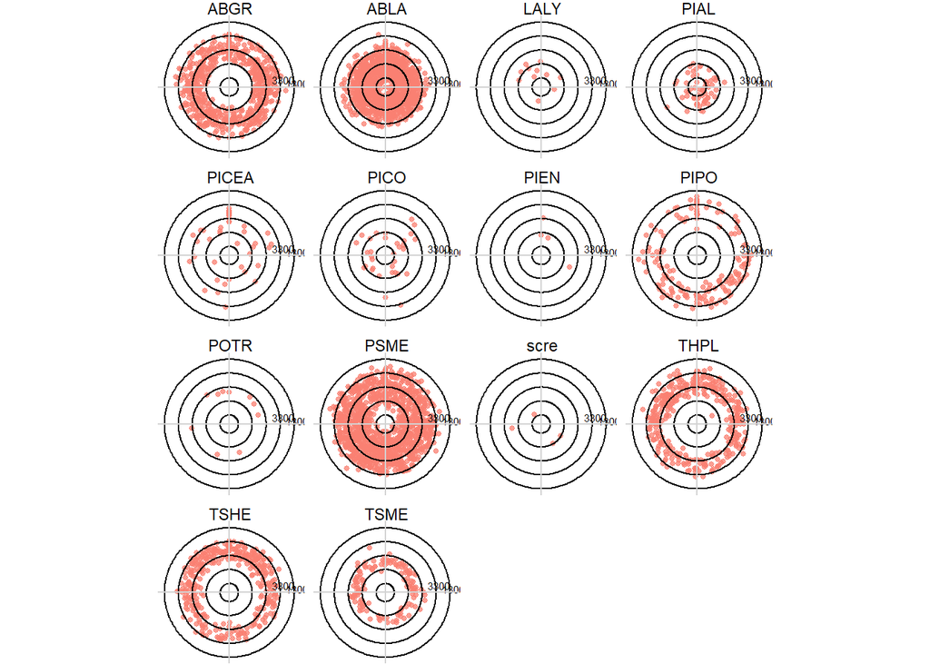

```r
min_elev <- min(floor(stand_err$ELEVFT))
max_elev <- max(ceiling(stand_err$ELEVFT))
stand_err |>
  mutate(asp_rotated = (90-ASPECT) %% 360,
         elev_band = (cut(ELEVFT,
                         breaks = seq(min(floor(ELEVFT)),
                                      max(ceiling(ELEVFT)),
                                      by = 500),
                         labels = FALSE,
                         include.lowest = TRUE)-1)*500 + min_elev,
         targ_x = (max_elev-ELEVFT)*cos(pi*asp_rotated/180),
         targ_y = (max_elev-ELEVFT)*sin(pi*asp_rotated/180)) |>
  ggplot()+
  geom_point(aes(x = targ_x, y = targ_y), alpha = 0.75, color = 'salmon', size = 1)+
  geom_circle(data = data.frame(x0 = 0, y0 = 0,
                                r = seq(min_elev, max_elev, by = 2000)),
              aes(x0 = x0, y0 = y0, r = r))+
  annotate(geom = 'text', x = max_elev, y = 500, label = '1300', size = 2)+
  annotate(geom = 'text', x = max_elev-2000, y = 1000, label = '3300', size = 2)+
  geom_hline(aes(yintercept = 0), color = 'lightgrey')+
  geom_vline(aes(xintercept = 0), color = 'lightgrey')+
  # annotate(geom = 'text', label = 'N', x = 0, y = 10000)+
  # annotate(geom = 'text', label = 'W', x = -10000, y = 0)+
  # annotate(geom = 'text', label = 'S', x = 0, y = -10000)+
  # annotate(geom = 'text', label = 'E', x = 10000, y = 0)+
  coord_fixed()+
  theme_void()+
  labs(x = '', y = '')+
  facet_wrap(facets = vars(dominant_sp))
```

Unsurprisingly, subalpine fir, subalpine larch, whitebark pine, and lodgepole pine habitat types are all high elevations. Spruces, hemlocks, grand fir, and cedar habitat types make up the middle elevation bands. Douglas-fir is at most elevations except the very highest north-facing slopes and the lowest elevations. Ponderosa pine habitat types are somewhat more concentrated on south-facing slopes, and north-facing PIPO habitat types are at lower elevations.

Simplified habitat types (just the most common ones):

**Code to generate figure**

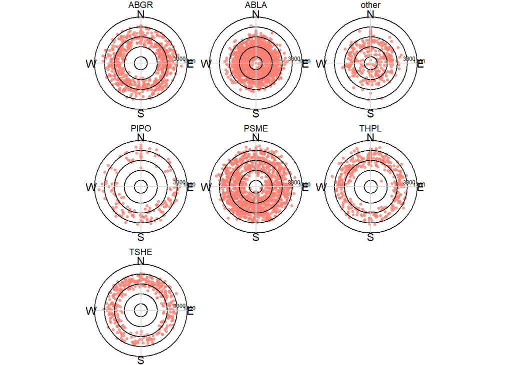

```r
stand_err |>
  mutate(asp_rotated = (90-ASPECT) %% 360,
         elev_band = (cut(ELEVFT,
                         breaks = seq(min(floor(ELEVFT)),
                                      max(ceiling(ELEVFT)),
                                      by = 500),
                         labels = FALSE,
                         include.lowest = TRUE)-1)*500 + min_elev,
         targ_x = (max_elev-ELEVFT)*cos(pi*asp_rotated/180),
         targ_y = (max_elev-ELEVFT)*sin(pi*asp_rotated/180),
         dominant_sp_simple = ifelse(dominant_sp %in% common_habs, dominant_sp, 'other')) |>
  ggplot()+
  geom_point(aes(x = targ_x, y = targ_y), alpha = 0.75, color = 'salmon', size = 1)+
  geom_circle(data = data.frame(x0 = 0, y0 = 0,
                                r = seq(min_elev, max_elev, by = 2000)),
              aes(x0 = x0, y0 = y0, r = r))+
  annotate(geom = 'text', x = max_elev, y = 500, label = '1300', size = 2)+
  annotate(geom = 'text', x = max_elev-2000, y = 1000, label = '3300', size = 2)+
  geom_hline(aes(yintercept = 0), color = 'lightgrey')+
  geom_vline(aes(xintercept = 0), color = 'lightgrey')+
  annotate(geom = 'text', label = 'N', x = 0, y = 10000)+
  annotate(geom = 'text', label = 'W', x = -10000, y = 0)+
  annotate(geom = 'text', label = 'S', x = 0, y = -10000)+
  annotate(geom = 'text', label = 'E', x = 10000, y = 0)+
  coord_fixed()+
  theme_void()+
  labs(x = '', y = '')+
  facet_wrap(facets = vars(dominant_sp_simple))
```

### Ecoregion

Ecoregion polygons from https://earthworks.stanford.edu/catalog/stanford-tj200ct4975; forest boundaries from https://data.fs.usda.gov/geodata/edw/datasets.php?dsetCategory=boundaries.

**Code to generate figure**

```r
eco_poly <- st_read(here('raw_data', 'ecoregions', 'ecoregp075.shp')) |>
  st_transform(crs = st_crs(ie_buffered)) |>
  st_crop(ie_buffered)
```

**Code to generate figure**

```r
forest_poly <- st_read(here('raw_data', 'forest_admin_bnds', 'S_USA.BdyAdm_LSRS_AdministrativeForest.shp')) |>
  st_transform(crs = st_crs(ie_buffered)) |>
  st_crop(ie_buffered) |>
  select(ADMINFORES, REGION, FORESTNUMB, FORESTNAME)
```

**Code to generate figure**

```r
stand_err_eco_spat <- st_intersection(stand_err_spat, eco_poly)
```

**Code to generate figure**

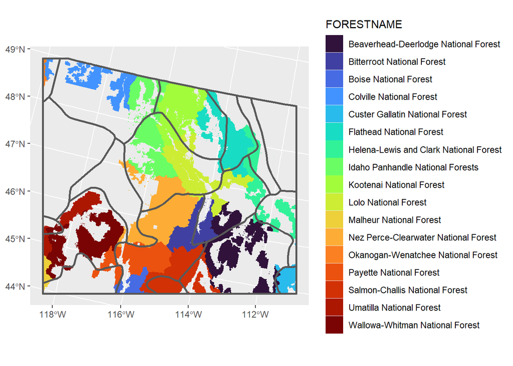

```r
ggplot()+
  geom_sf(data = forest_poly, aes(fill = FORESTNAME, color = FORESTNAME))+
  geom_sf(data = eco_poly, fill = NA, lwd = 1)+
  scale_color_viridis_d(option = 'turbo')+
  scale_fill_viridis_d(option = 'turbo')
```

Generally, NF boundaries (filled shapes) are not perfectly aligned with ecoregion (at the section level). Most forests cover 2-3 ecosections.

**Code to generate figure**

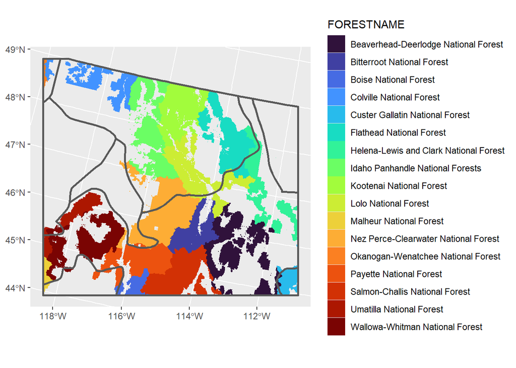

```r
ggplot()+
  geom_sf(data = forest_poly, aes(fill = FORESTNAME, color = FORESTNAME))+
  geom_sf(data = summarize(group_by(eco_poly, PROVINCE)), fill = NA, lwd = 1)+
  scale_color_viridis_d(option = 'turbo')+
  scale_fill_viridis_d(option = 'turbo')
```

We get a good amount of variety in terms of which national forests are in which ecoprovinces.

**Code to generate figure**

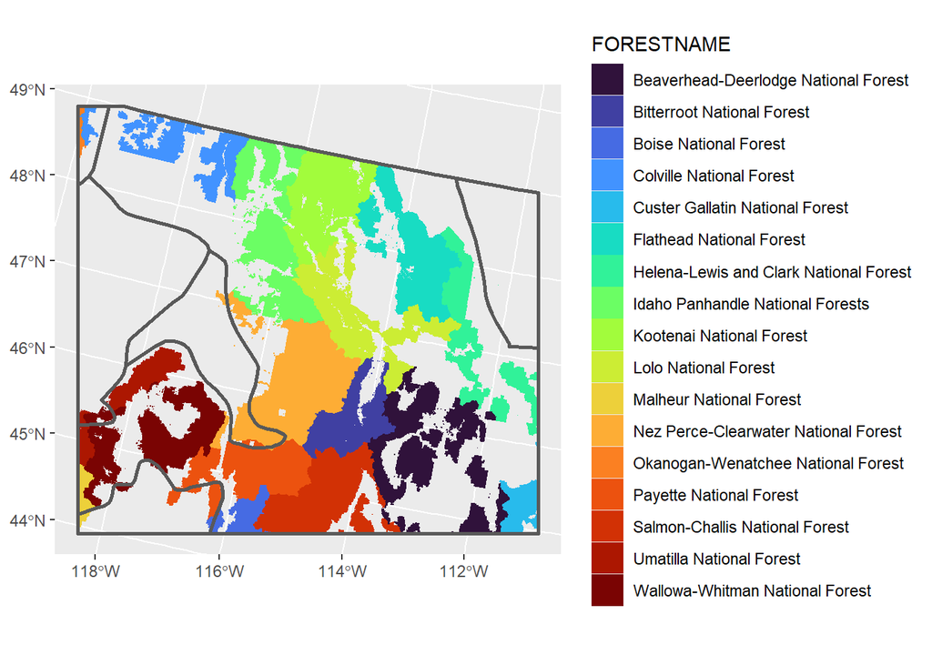

```r
ggplot()+
  geom_sf(data = forest_poly, aes(fill = FORESTNAME, color = FORESTNAME))+
  geom_sf(data = summarize(group_by(eco_poly, DIVISION)), fill = NA, lwd = 1)+
  scale_color_viridis_d(option = 'turbo')+
  scale_fill_viridis_d(option = 'turbo')
```

At the division level, most forests fall within one division.

**Code to generate figure**

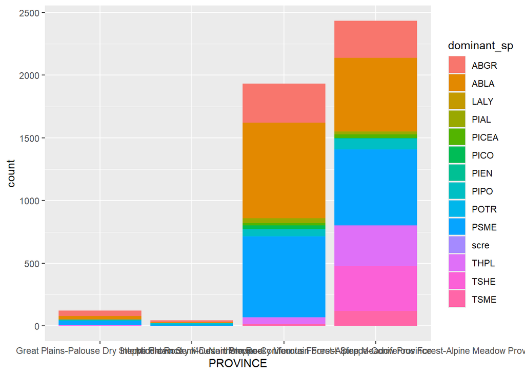

```r
stand_err_eco_spat |>
  st_drop_geometry() |>
  ggplot(aes(x = PROVINCE, fill = dominant_sp))+
  geom_bar()
```

**Code to generate figure**

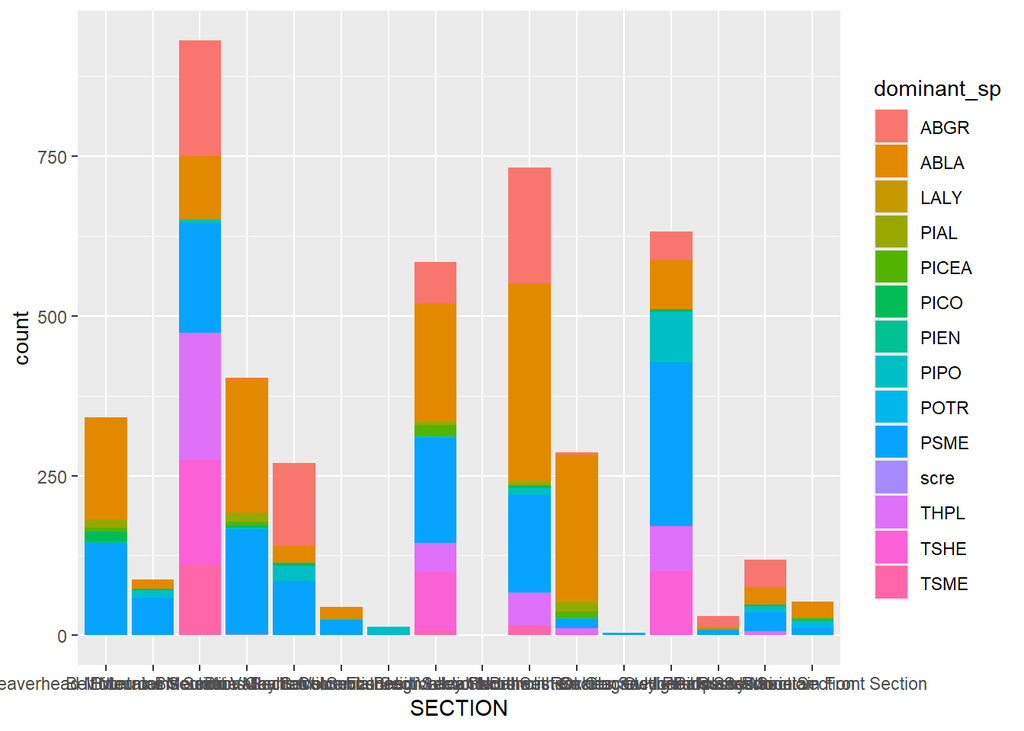

```r
stand_err_eco_spat |>
  st_drop_geometry() |>
  ggplot(aes(x = SECTION, fill = dominant_sp))+
  geom_bar()
```

There’s good mixing of habitat types within ecoprovince and ecosection, which is a good sign.

### Eco Hierarchy and SD

**Code to generate figure**

```r
tree_err_spat <- trees_err |>
  filter(!is.na(dg_err)) |>
  select(fvs_sp, LONGITUDE, LATITUDE, dg_err) |>
  st_as_sf(coords = c('LONGITUDE', 'LATITUDE'),
                           crs = 'epsg:4269') |>
  st_transform(crs = st_crs(ie_buffered)) |>
  st_intersection(eco_poly)
```

**Code to generate figure**

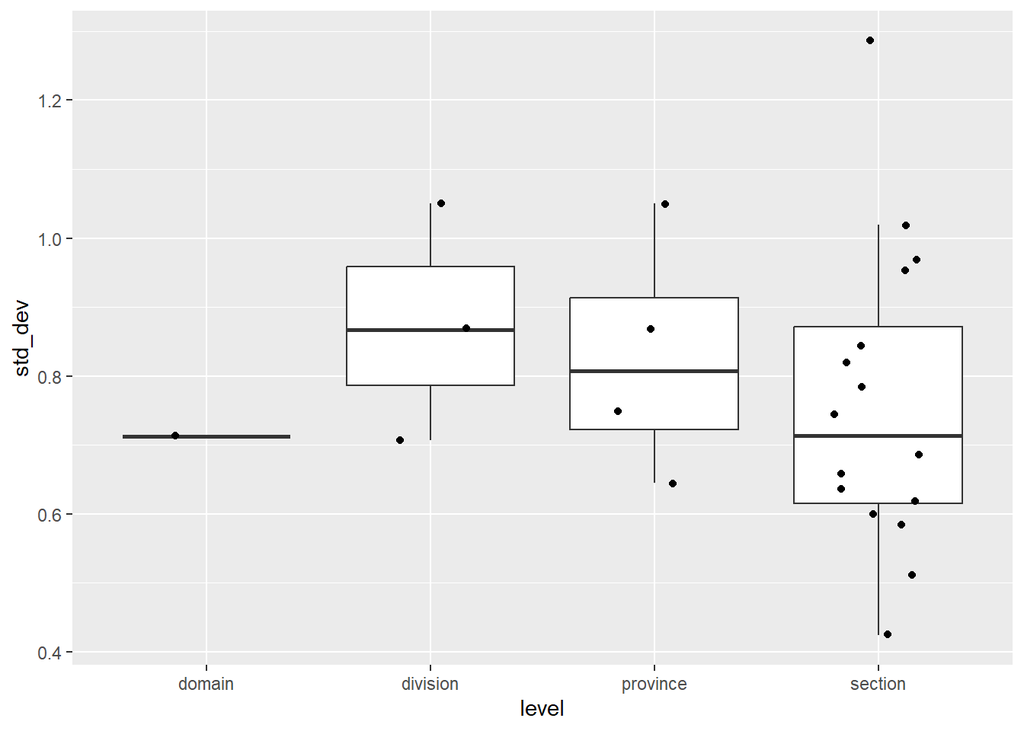

```r
dom_summ <- tree_err_spat |>
  st_drop_geometry() |>
  rename(name = DOMAIN) |>
  group_by(name) |>
  summarize(std_dev = sd(dg_err, na.rm = TRUE),
            n = n(),
            level = 'domain')

div_summ <- tree_err_spat |>
  st_drop_geometry() |>
  rename(name = DIVISION) |>
  group_by(name) |>
  summarize(std_dev = sd(dg_err, na.rm = TRUE),
            n = n(),
            level = 'division')

prov_summ <- tree_err_spat |>
  st_drop_geometry() |>
  rename(name = PROVINCE) |>
  group_by(name) |>
  summarize(std_dev = sd(dg_err, na.rm = TRUE),
            n = n(),
            level = 'province')

sect_summ <- tree_err_spat |>
  st_drop_geometry() |>
    rename(name = SECTION) |>
  group_by(name) |>
  summarize(std_dev = sd(dg_err, na.rm = TRUE),
            n = n(),
            level = 'section')

eco_sd <- bind_rows(dom_summ, div_summ, prov_summ, sect_summ) |>
  mutate(level = factor(level,
                        levels = c('domain', 'division', 'province', 'section'),
                        ordered = TRUE))

ggplot(eco_sd)+
  geom_boxplot(aes(x = level, y = std_dev), outliers = FALSE)+
  geom_jitter(aes(x = level, y = std_dev), width = 0.2)
```